# Probabilidad y Estadística II Clase 8

Nicolás Mejía Martínez

> Se realizó un experimento para estudiar los efectos de la temperatura y el tipo de horno sobre la vida de un componente en particular. En el experimento se utilizaron 4 tipos de horno y 3 niveles de temperatura. Se asignaron 24 piezas al azar, 2 para cada combinación de tratamientos y los resultados se encuentran en Sicua

Para el ejercicio necesitaremos 2 librerias $dplyr$ que ya conocemos y $multcompView$ para la prueba de Tukey

```r
library(multcompView)
library(dplyr)
```

Primero leemos los datos, revisamos sus tipos y hacemos los cambios necesarios.

```r
Datos <- read.csv2("F:/Probabilidad y Estadística II/Clase 9/Datos2_Clase9.csv")
str(Datos)
```

```
## 'data.frame':    24 obs. of  4 variables:
##  $ Pieza      : int  1 2 3 4 5 6 7 8 9 10 ...
##  $ Temperatura: int  500 500 500 500 500 500 500 500 550 550 ...
##  $ Horno      : Factor w/ 4 levels "O1","O2","O3",..: 1 1 2 2 3 3 4 4 1 1 ...
##  $ Vida       : int  227 221 214 259 225 236 260 229 187 208 ...
```

```r
Datos$Temperatura<-as.factor(Datos$Temperatura)
```

Como Tukey es una prueba de comparación múltiple que nos dice cuales son los pares de medias diferentes en caso de que existan diferencias, debe hacerse despues del ANOVA. Los resultados del ANOVA deben guardarse en una variable que luego será utilizada para hacer la prueba de Tukey

```r
Anova<-aov(Vida ~ Horno*Temperatura, data = Datos)
summary(Anova)
```

```
##                   Df Sum Sq Mean Sq F value  Pr(>F)
## Horno              3   4963  1654.4   5.179 0.01589 *
## Temperatura        2   5194  2597.0   8.130 0.00586 **
## Horno:Temperatura  6   3126   521.0   1.631 0.22152
## Residuals         12   3834   319.5
## ---
## Signif. codes:  0 '***' 0.001 '**' 0.01 '*' 0.05 '.' 0.1 ' ' 1
```

Antes de la prueba podemos explorar las medias por nivel de cada factor.

```r
Medias<-Datos%>% group_by(Horno) %>% summarise(Media=mean(Vida))
Medias
```

```
## # A tibble: 4 x 2
##   Horno Media
##   <fct> <dbl>
## 1 O1     203.
## 2 O2     204.
## 3 O3     214.
## 4 O4     239.
```

Ahora la prueba de tukey se hace con el comando $TukeyHSD$ especificando el anova que se desarrolló anteriormente, el factor/interacción del que se quieren hacer comparacions y se puede especificar un nivel de confianza (por defecto es del 0.95)

```r
Tukey<-TukeyHSD(Anova,"Horno",conf.level=0.95)
Tukey
```

```
##   Tukey multiple comparisons of means
##     95% family-wise confidence level
##
## Fit: aov(formula = Vida ~ Horno * Temperatura, data = Datos)
##
## $Horno
##           diff       lwr      upr     p adj
## O2-O1  1.00000 -29.63672 31.63672 0.9996547
## O3-O1 10.50000 -20.13672 41.13672 0.7426877
## O4-O1 35.66667   5.02995 66.30338 0.0213698
## O3-O2  9.50000 -21.13672 40.13672 0.7945573
## O4-O2 34.66667   4.02995 65.30338 0.0253255
## O4-O3 25.16667  -5.47005 55.80338 0.1220652
```

Tambien podemos hacer una grafica de las comparaciones con el comando plot

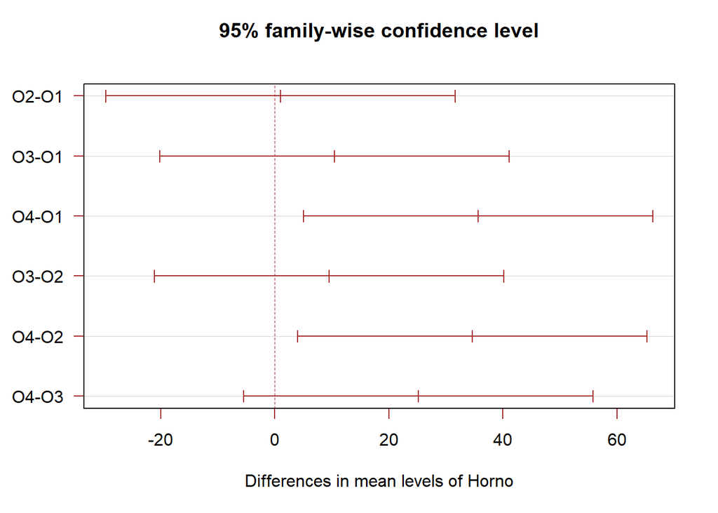

```r
plot(Tukey , las=1 , col="brown")
```